# Week14_Friday slides

## Week 14 Friday

**Announcements**

- A09 due Wednesday, 5/6
- A10 (report) due **May 14th at midnight**
- A10 (poster) due **May 8th at midnight**. There are **a lot** of posters to print.
- Poster design workshop/lecture on Monday.

**Goals**

- Introduction to probabilistic occupancy: Part 3 (wrap-up)
- Work session

### Part 1: Propagating uncertainty from timestep to timestep

[figure not shown]

#### Propagating Uncertainty Using Model

1. Compute new estimate for $\hat{x}_k$, transform into a change in cell $\Delta j$
2. Shift PDF from prior timestep using $\Delta j$
3. Convolve to obtain new PDF $$Bel(j)_k = \sum_{i=0}^{n-1} H(i)\cdot Bel\left(j+i-\frac{n-1}{2}\right)_{k-1}$$

## As an algorithm (Python pseudocode):

**for all timesteps k do:**

- $\hat{x}_k = f(\hat{x}_{k-1},u_{k-1})\leftarrow$ update model prediction
- $\hat{j}_{k} = int\left(\frac{m}{d}\left(\hat{x}_k -\frac{d}{2m} \right) \right)\leftarrow$ update cell estimate
- $\Delta j = \hat{j}_k-\hat{j}_{k-1}\leftarrow$ update shift
- $Bel_{old} = Bel \leftarrow$ copy belief from prior timestep
- for b in range(max(0,$\Delta j$),min(m+$\Delta j$,m)):
  - $Bel(j+\Delta j) = Bel_{old}(j)\leftarrow$ shift belief
- for r in range(0,m):
  - $Bel[r]_{k}= \sum_{i=0}^{p-1} H[r]\cdot Bel\left[r+i-\frac{p-1}{2}\right]\leftarrow$ update belief
- $\hat{j}_k = argmax(Bel)\leftarrow$ most likely estimate
- $\hat{x}_k = \hat{j}_k\frac{d}{m} + \frac{d}{2m}\leftarrow$ convert back to an estimate in true units

### As Python Code

```
import numpy as np
import cv2
import matplotlib.pyplot as plt

#function to update dynamics
def updateMotion(x,u):
    #just a simple model for now
    x = x+u
    return x


#function to get the index j in Bel given an x.
def getCell(x,Bel,d):
    m = np.size(Bel)
    j = int((x-d/(2*m))*m/d)
    return j

#function to shift Bel probabilities given delta_j
def shiftBelief(Bel,delta_j):
    m= np.size(Bel)
    #copy the Bel to keep an old copy
    Belold = Bel
    Bel = np.zeros(np.size(Bel))
    #now loop through and shift
    #print("delta_j = "+str(delta_j))
    #print(range(max([0,delta_j]),min(m-delta_j,m)))
    for j in range(max([0,delta_j]),min(m-delta_j,m)):
        # print("j="+str(j))
        Bel[j+delta_j]=Belold[j]
    return Bel

#function to get the x coordinate of most likely j's center
def getEstimate(j,Bel,d):
    m = np.size(Bel)
    x = j*d/m + d/(2*m)
    return x

# Function to display our belief histogram
def dispBel(Bel):
    #create an image to display to show us our belief
    Bel_image = np.array([Bel])
    Bel_image = np.dot(np.ones((np.size(Bel),1)),Bel_image)
    Bel_image = cv2.resize(Bel_image,(3*np.size(Bel),3*np.size(Bel)))
    Bel_image = Bel_image/np.max(Bel)
    plt.imshow(Bel_image,cmap='gray')

def doPropagate(Bel,xhat,u):
    global d,Hx
    #step 0: where were we?
    j_old = getCell(xhat,Bel,d)
    #step 1: propagate estimate using motion model
    xhat = updateMotion(xhat,u)
    # print("after update, xhat = "+str(xhat))
    #step 2: get new jhat
    jhat = getCell(xhat,Bel,d)
    # print("jhat- ="+str(jhat))
    #step 3: calculate shift
    delta_j = jhat-j_old
    # print("jhat = "+str(jhat)+", j_old = "+str(j_old)+", delta = "+str(delta_j))
    #update j old for next time
    j_old = jhat
    #step 4: shift belief!!
    Bel = shiftBelief(Bel,delta_j)
    #step 5: update Belief with uncertainty by convolving.
#     print(Bel)
    Bel = np.convolve(Hx,Bel,'same')
#     print(Bel)
    #get new jhat
    jhat = np.argmax(Bel)
    #get new xhat
    xhat = getEstimate(jhat,Bel,d)
    return Bel,xhat
#now put these into a loop.
#define a "Bel" which is actually an array of probabilities
Bel = np.zeros(25)
d = 1 #1cm grid 0.1m long

#initialize our belief to a particular position
x0 = 0.1
j0 = getCell(x0,Bel,d)

#initialize our estimates.
xhat = x0
jhat = j0
Bel[jhat] = 1.0
# print(Bel)

#define a histogram H that represents uncertainty in motion model
Hx = np.array([.3,.4,.3])
print("H = "+str(Hx))
quit = False
u = 0
j_old = jhat
k=0


fig = plt.figure(figsize=(8,4))
plt.subplot(1,4,1)
dispBel(Bel)
plt.title('k = '+str(0))
while k<3:
    Bel,xhat = doPropagate(Bel,xhat,.05)
    plt.subplot(1,4,k+2)
    dispBel(Bel)
    plt.title('k = '+str(k+1))
    k+=1
```

```
H = [0.3 0.4 0.3]
```

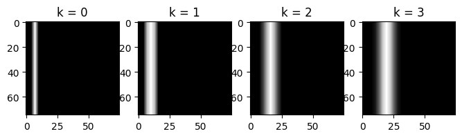

### Part 2: Updating Prior Belief Using Bayes's Rule

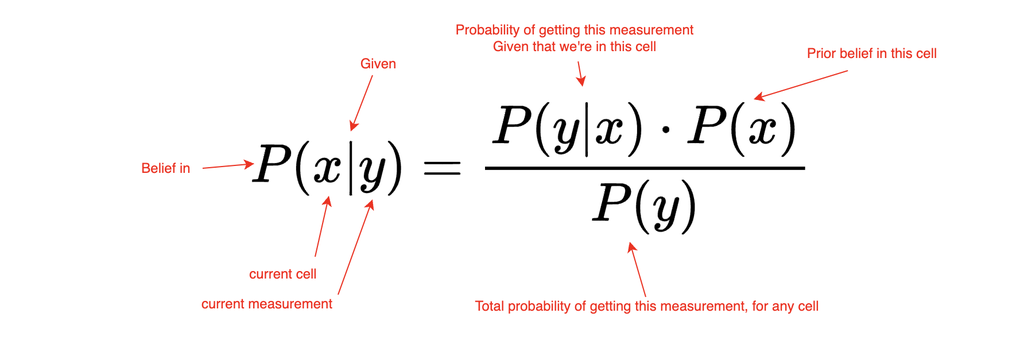

### Part 3: Putting it all together to get "The Histogram Filter"

**Terminology**

- $Bel^\rightarrow_k$: Shifted prior PDF using $\Delta j$ for timestep $k$ given motion prediction from $t_{k-1}$ to $t_k$
- $Bel^-_k$: Prior belief updated using convolution of motion uncertainty PDF with $Bel^\rightarrow_k$
- $Bel^{+}_k$: Belief updated using Bayes's Rule applied to $Bel^-_k$

$$ Bel[j]^+_k = Bel(j|(Bel[j]^-_k,z_k)) = \frac{P(z_k|j)\cdot Bel[j]^-_k}{P(z_k)}$$

### Part 3: Putting it all together to get "The Histogram Filter"

### How do we handle $P(z_k|j)$?

- If we got a measurement that told us we were in cell $p$, how likely is it that we're actually in cell $j$?

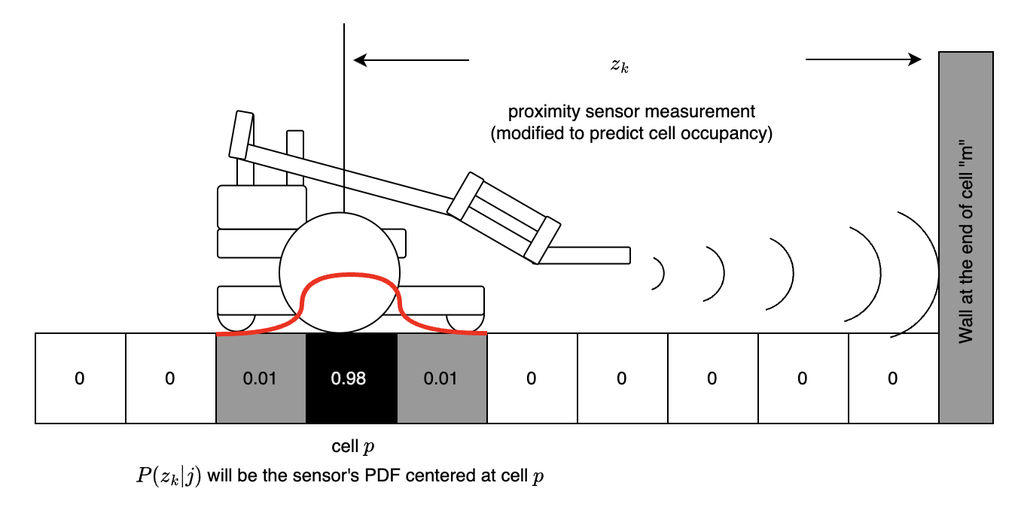

## How do we handle $P(z_k)$?

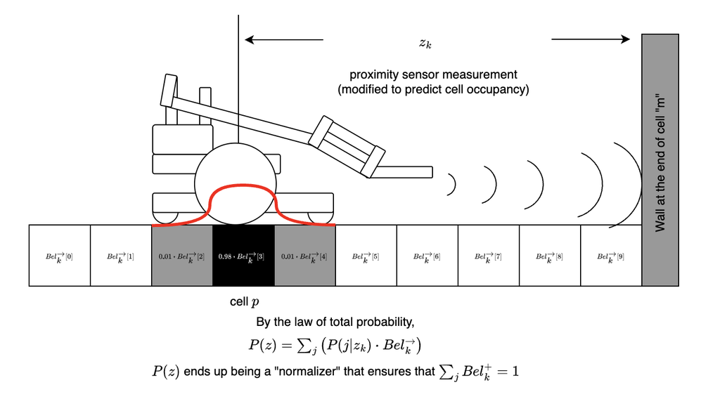

### Part 3: Putting it all together to get "The Histogram Filter"

**Algorithm**

- For all timesteps k do:
  - Using model and input, for all cells $j$ in map with best belief $Bel^+_{k-1}$ do:
    - Compute $Bel^\rightarrow_k[j]$
  - For all cells $j$ in map with shifted belief $Bel^\rightarrow_k[j]$ do:
    - Compute $Bel^-_k$ by convolving model uncertainty PDF over $Bel^\rightarrow_k$
  - If a new measurement $z_k$ is available:
    - For all cells $j$ in map with prior belief $Bel^-_k$ do:
      - Compute $P(z_k|j)$ using PDF of measurement error and best cell estimate.
      - Compute un-normalized updated belief $Bel^+_k[j] = P(z_k|j)\cdot Bel^-_k[j]$
    - Initialize P(z) = 0
    - For all cells $j$ in map with belief $Bel^\rightarrow_k$ do:
      - $P(z) = P(z) + Bel^\rightarrow_k[j]*P(z_k|j)$
    - For all cells $j$ in map with un-normalized belief $Bel^+_k$ do:
      - $Bel^+_k[j] = Bel^+_k[j]/P(z)$
  - If no new measurement $z_k$ is available, $Bel^+_k = Bel^-_k$ (propagation is our best guess)

## As Python Code:

```
import numpy as np
import cv2
import matplotlib.pyplot as plt

#function to update dynamics
def updateMotion(x,u):
    #just a simple model for now
    x = x+u
    return x


#function to get the index j in Bel given an x.
def getCell(x,Bel,d):
    m = np.size(Bel)
    j = int((x-d/(2*m))*m/d)
    return j

#function to shift Bel probabilities given delta_j
def shiftBelief(Bel,delta_j):
    m= np.size(Bel)
    #copy the Bel to keep an old copy
    Belold = Bel.copy()
    Bel = np.zeros(np.size(Bel))
    #now loop through and shift
    #print(range(max([0,delta_j]),min(m-delta_j,m)))
    for j in range(min([0,delta_j]),min(m-delta_j,m)):
        Bel[j+delta_j]=Belold[j]
    return Bel

#function to get the x coordinate of most likely j's center
def getEstimate(j,Bel,d):
    m = np.size(Bel)
    x = j*d/m + d/(2*m)
    return x

#given a cell j, how likely is it that we would get a measurement z?
def getPzx(z,Hz,Bel,d):
    #store the half-size of the measurement histogram
    halfHz = int((np.size(Hz)-1)/2)
    #create a padded version that will handle cells through range of Bel
    Pzx_padded = np.zeros(np.size(Bel)+2*halfHz)
    #now determine which cell the measurement SHOULD be in w/o noise
    zj = getCell(z,Bel,d)
    #now fill in Pzx with this histogram, centered at the right spot
    Pzx_padded[zj-halfHz:zj-halfHz+np.size(Hz)] = Hz
    #now slice the histogram and return
    return Pzx_padded[halfHz-1:np.size(Bel)]


def bayesUpdate(Bel,Hz,z,d):
    #fill in probability of getting this measurement given z
    Pzx = getPzx(z,Hz,Bel,d)
    #initialize Pz
    Pz = 0
    #now loop through all cells and apply Bayes's rule
    for j in range(0,np.size(Bel)):
        Bel[j] = Bel[j]*Pzx[j]
        Pz+=Bel[j]
    print("Pz = "+str(Pz))
    #now loop through and normalize using Pz
    for j in range(0,np.size(Bel)):
        Bel[j]= Bel[j]/Pz
    return Bel


# Function to display our belief histogram
def dispBel(Bel,xtrue,d):
    #create an image to display to show us our belief
    Bel_image = np.array([Bel],dtype=np.float32)
    Bel_image = np.dot(np.ones((np.size(Bel),1),dtype=np.float32),Bel_image)

    Bel_image = cv2.normalize(Bel_image, None, 0, 1, cv2.NORM_MINMAX, dtype=cv2.CV_32F)
    Bel_image = cv2.cvtColor(Bel_image, cv2.COLOR_GRAY2BGR)
    jtrue = getCell(xtrue,Bel,d)
    Bel_image = cv2.resize(Bel_image,(np.size(Bel),np.size(Bel)))
    plt.figure(figsize=(4,4))
    plt.imshow(Bel_image,cmap='gray')
    plt.axis('equal')
    plt.plot([jtrue,jtrue],[0,np.shape(Bel_image)[0]-1],'r')
```

## Python Implementation

```
import numpy as np
import cv2
import matplotlib.pyplot as plt

#function to update dynamics
def updateMotion(x,u):
    #just a simple model for now
    x = x+u
    return x


#function to get the index j in Bel given an x.
def getCell(x,Bel,d):
    m = np.size(Bel)
    j = int((x-d/(2*m))*m/d)
    return j

#function to shift Bel probabilities given delta_j
def shiftBelief(Bel,delta_j):
    m= np.size(Bel)
    #copy the Bel to keep an old copy
    Belold = Bel.copy()
    Bel = np.zeros(np.size(Bel))
    #now loop through and shift
    #print(range(max([0,delta_j]),min(m-delta_j,m)))
    for j in range(min([0,delta_j]),min(m-delta_j,m)):
        Bel[j+delta_j]=Belold[j]
    return Bel

#function to get the x coordinate of most likely j's center
def getEstimate(j,Bel,d):
    m = np.size(Bel)
    x = j*d/m + d/(2*m)
    return x

#given a cell j, how likely is it that we would get a measurement z?
def getPzx(z,Hz,Bel,d):
    #store the half-size of the measurement histogram
    halfHz = int((np.size(Hz)-1)/2)
    #create a padded version that will handle cells through range of Bel
    Pzx_padded = np.zeros(np.size(Bel)+2*halfHz)
    #now determine which cell the measurement SHOULD be in w/o noise
    zj = getCell(z,Bel,d)
    #now fill in Pzx with this histogram, centered at the right spot
    Pzx_padded[zj-halfHz:zj-halfHz+np.size(Hz)] = Hz
    #now slice the histogram and return
    return Pzx_padded[halfHz-1:np.size(Bel)]


def bayesUpdate(Bel,Hz,z,d):
    #fill in probability of getting this measurement given z
    Pzx = getPzx(z,Hz,Bel,d)
    #initialize Pz
    Pz = 0
    #now loop through all cells and apply Bayes's rule
    for j in range(0,np.size(Bel)):
        Bel[j] = Bel[j]*Pzx[j]
        Pz+=Bel[j]
    print("Pz = "+str(Pz))
    #now loop through and normalize using Pz
    for j in range(0,np.size(Bel)):
        Bel[j]= Bel[j]/Pz
    return Bel


# Function to display our belief histogram
def dispBel(Bel,xtrue,d):
    #create an image to display to show us our belief
    Bel_image = np.array([Bel],dtype=np.float32)
    Bel_image = np.dot(np.ones((np.size(Bel),1),dtype=np.float32),Bel_image)

    Bel_image = cv2.normalize(Bel_image, None, 0, 1, cv2.NORM_MINMAX, dtype=cv2.CV_32F)
    Bel_image = cv2.cvtColor(Bel_image, cv2.COLOR_GRAY2BGR)
    jtrue = getCell(xtrue,Bel,d)
    Bel_image = cv2.resize(Bel_image,(np.size(Bel),np.size(Bel)))
    plt.figure(figsize=(4,4))
    plt.imshow(Bel_image,cmap='gray')
    plt.axis('equal')
    plt.plot([jtrue,jtrue],[0,np.shape(Bel_image)[0]-1],'r')
```

.

.

.

.

.

## Initializing a Simulation:

```
#define a "Bel" which is actually an array of probabilities
d = 0.25 #1cm grid 25cm long
cellSize = 0.01
Bel = np.zeros(int(d/cellSize))
print("Bel size: "+str(np.shape(Bel)))

#initialize our belief to a particular position
x0 = 0.03
j0 = getCell(x0,Bel,d)
print("j0 = "+str(j0))
#initialize our estimates.
xhat = x0
xtrue = x0
jhat = j0
Bel[jhat] = 1.0

#define a histogram Hx that represents uncertainty in motion model
Hx = np.array([.2,.6,.2])
#Define histogram Hz representing measurement noise
Hz = np.array([.025, .95, .025])
print("Hx = "+str(Hx))
print("Hz = "+str(Hz))
#assume motion is the same for every timestep.
u = 0.01
#initialize last value of j
j_old = jhat
#initialize timestep counter.
k=0
#create a "flag" that tells us when we have a measurement available.
new_measurement = False
#show the initial belief
dispBel(Bel,xtrue,d)
print(Bel)
plt.title("Timestep k = "+str(k)+", measurement = "+str(new_measurement))
```

[output not shown]

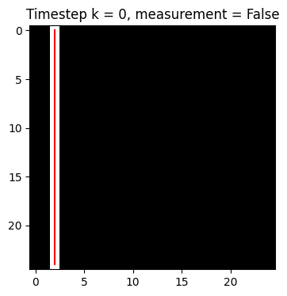

## Updating At Each Timestep (no measurement)

```
#step 1: propagate estimate using motion model
xhat = updateMotion(xhat,u)
#keep track of "true" x as well
xtrue = updateMotion(xtrue,u)
print("after update, xhat- = "+str(xhat))
#step 2: get new jhat
jhat = getCell(xhat,Bel,d)
print("jhat- ="+str(jhat))
#step 3: calculate shift
delta_j = jhat-j_old
# print("delta_j = "+str(delta_j))
#update j old for next time
j_old = jhat
#step 4: shift belief!!
Bel = shiftBelief(Bel,delta_j)
#step 5: update Belief with uncertainty by convolving.
Bel = np.convolve(Hx,Bel,'same')
#get new jhat
jhat = np.argmax(Bel)
#get new xhat
xhat = getEstimate(jhat,Bel,d)
if new_measurement:
    #create a fake measurement-- assume came from a noisy dist sensor
    #for now, assume Gaussian noise w/ std of .025cm. This means
    #that roughly, 95% conf is within a cell (4 std total, 2 each way).
    z = xtrue + .00025*np.random.randn()
    #now pass z and Hz to bayes update function
    Bel = bayesUpdate(Bel,Hz,z,d)
#get new jhat
jhat = np.argmax(Bel)
#get new xhat
xhat = getEstimate(jhat,Bel,d)

# print("xhat+: "+str(xhat)+", u = "+str(u)+", jhat+ = "+str(jhat))
#display Bel for us.
print("Bel+ is:"+str(Bel))
dispBel(Bel,xtrue,d)
k=k+1
plt.title("Timestep k = "+str(k)+", measurement = "+str(new_measurement))
```

## Updating At Each Timestep (no measurement)

```
after update, xhat- = 0.04
jhat- =3
Bel+ is:[0.  0.  0.2 0.6 0.2 0.  0.  0.  0.  0.  0.  0.  0.  0.  0.  0.  0.  0.
 0.  0.  0.  0.  0.  0.  0. ]
```

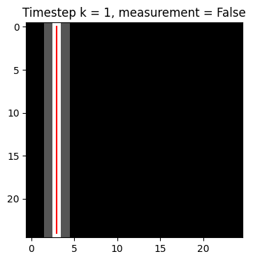

## Updating At Each Timestep (no measurement)

```
after update, xhat- = 0.045
jhat- =4
Bel+ is:[0.   0.   0.04 0.24 0.44 0.24 0.04 0.   0.   0.   0.   0.   0.   0.
 0.   0.   0.   0.   0.   0.   0.   0.   0.   0.   0.  ]
```

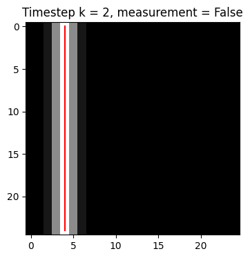

## Updating At Each Timestep (no measurement)

```
after update, xhat- = 0.055
jhat- =5
Bel+ is:[0.    0.    0.008 0.072 0.24  0.36  0.24  0.072 0.008 0.    0.    0.
 0.    0.    0.    0.    0.    0.    0.    0.    0.    0.    0.    0.
 0.   ]
```

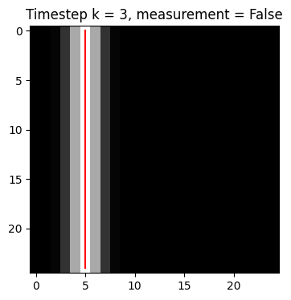

## Updating At Each Timestep (with measurement)

[output not shown]

[figure not shown]

## Updating at each timestep (no measurement)

[output not shown]

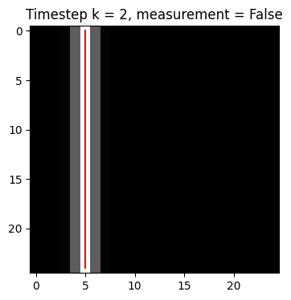

## In Summary:

A histogram filter allows you to fuse model predictions an measurements in a probabilistic way! Measurements "shrink" The belief PDF, while model updates inflate it. This technique is often used for map-based localization with sensors like LIDAR and cameras. For an idea of how this can be applied in 2D, see [This post](https://atsushisakai.github.io/PythonRobotics/modules/localization/histogram_filter_localization/histogram_filter_localization.html). For an idea of how Bayesian inference can be extended to more complex tasks, see [This paper](http://driving.stanford.edu/papers/ICRA2010.pdf) From ICRA 2010 by Jesse Levinson and Sebastian Thrun.